# Analysis of Elections in India

## By Mohd Hassaan

## Introduction

> **Source**: https://dataverse.harvard.edu/dataset.xhtml?persistentId=doi:10.7910/DVN/26526

### Initial Exploration

### Structure of the data

```
## [1] 327881     11
```

```
## [1] 73081    11
```

```
## 'data.frame':    327881 obs. of  11 variables:
##  $ st_name   : Factor w/ 30 levels "Andhra Pradesh",..: 1 1 1 1 1 1 1 1 1 1 ...
##  $ year      : num  1978 1978 1978 1978 1978 ...
##  $ ac_no     : int  1 1 1 1 1 2 2 2 3 3 ...
##  $ ac_name   : Factor w/ 6248 levels "","101. Jalna",..: 2246 2246 2246 2246 2246 5474 5474 5474 5692 5692 ...
##  $ ac_type   : Factor w/ 5 levels "BL","GEN","SANGH",..: 2 2 2 2 2 2 2 2 2 2 ...
##  $ cand_name : Factor w/ 220531 levels "'Kumar' Yashwant Raj Singh",..: 110728 12338 209117 86830 25209 59204 207119 63764 71822 178749 ...
##  $ cand_sex  : Factor w/ 4 levels "","F","M","O": 3 3 3 3 3 3 3 3 2 3 ...
##  $ partyname : Factor w/ 1663 levels "A S P","Aa S P",..: 642 642 664 665 736 664 665 736 665 664 ...
##  $ partyabbre: Factor w/ 1286 levels "","A S P","Aa S P",..: 497 497 493 494 585 493 494 585 494 493 ...
##  $ totvotpoll: int  813 1743 4427 19805 34251 2694 28251 42251 7998 22502 ...
##  $ electors  : int  83247 83247 83247 83247 83247 91272 91272 91272 90959 90959 ...
```

```
## 'data.frame':    73081 obs. of  11 variables:
##  $ st_name   : Factor w/ 43 levels "Andaman & Nicobar Islands",..: 1 1 1 1 1 1 1 1 1 1 ...
##  $ year      : int  1977 1977 1980 1980 1980 1980 1980 1980 1980 1980 ...
##  $ pc_no     : int  1 1 1 1 1 1 1 1 1 1 ...
##  $ pc_name   : Factor w/ 769 levels "Adilabad","Adilabad ",..: 38 38 38 38 38 38 38 38 38 38 ...
##  $ pc_type   : Factor w/ 5 levels "","GEN","SC",..: 2 2 2 2 2 2 2 2 2 2 ...
##  $ cand_name : Factor w/ 56601 levels "'Aids Man' Prakash Taterao Landge",..: 21485 28684 41951 1795 22788 21435 39393 23046 44757 21115 ...
##  $ cand_sex  : Factor w/ 4 levels "F","M","NULL",..: 2 2 2 2 2 2 2 2 2 2 ...
##  $ partyname : Factor w/ 1424 levels "A-Chik National Congress(Democratic)",..: 562 576 562 562 562 562 647 562 646 562 ...
##  $ partyabbre: Factor w/ 1071 levels "A S P","Aa S P",..: 427 423 427 427 427 427 499 427 497 427 ...
##  $ totvotpoll: int  25168 35400 109 125 405 470 717 1123 2034 15856 ...
##  $ electors  : int  85308 85308 96084 96084 96084 96084 96084 96084 96084 96084 ...
```

We have two Kind of data set. First one is of state election and other is for national, both data set have the same structure. It has state name, constituency name, total electorates, votes polled, cadidate name etc. The main visual difference between both data is that the few column name in national election data prefixes with pc(parliamentary constituency) and the same columns in state election data prefixes with ac(assembly constituency).

### Adding new variables

Before we go into any analysis we are going to add some new variables in the data. We are going to add a variable name proportion which gives us the proportion of vote a candidate get. the another variable is booleean variable which store the information about the candidate’s winning or loosing.

```
##          st_name year ac_no   ac_name ac_type                 cand_name
## 1 Andhra Pradesh 1978     1 Ichapuram     GEN          Manabala Ramarao
## 2 Andhra Pradesh 1978     1 Ichapuram     GEN               Appadu Sahu
## 3 Andhra Pradesh 1978     1 Ichapuram     GEN          Uppada Rangababu
## 4 Andhra Pradesh 1978     1 Ichapuram     GEN      Kalla Balarama Swamy
## 5 Andhra Pradesh 1978     1 Ichapuram     GEN Bendalam Venkatesam Sarma
## 6 Andhra Pradesh 1978     2   Sompeta     GEN       Ganni Padmanabharao
##   cand_sex                    partyname partyabbre totvotpoll electors
## 1        M                  Independent        IND        813    83247
## 2        M                  Independent        IND       1743    83247
## 3        M     Indian National Congress        INC       4427    83247
## 4        M Indian National Congress (I)     INC(I)      19805    83247
## 5        M                 Janata Party        JNP      34251    83247
## 6        M     Indian National Congress        INC       2694    91272
##    proportion
## 1 0.009766118
## 2 0.020937691
## 3 0.053179094
## 4 0.237906471
## 5 0.411438250
## 6 0.029516171
```

```
##                     st_name year pc_no                   pc_name pc_type
## 1 Andaman & Nicobar Islands 1977     1 Andaman & Nicobar Islands     GEN
## 2 Andaman & Nicobar Islands 1977     1 Andaman & Nicobar Islands     GEN
## 3 Andaman & Nicobar Islands 1980     1 Andaman & Nicobar Islands     GEN
## 4 Andaman & Nicobar Islands 1980     1 Andaman & Nicobar Islands     GEN
## 5 Andaman & Nicobar Islands 1980     1 Andaman & Nicobar Islands     GEN
## 6 Andaman & Nicobar Islands 1980     1 Andaman & Nicobar Islands     GEN
##           cand_name cand_sex                partyname partyabbre
## 1       K.R. Ganesh        M             Independents        IND
## 2 Manoranjan Bhakta        M Indian National Congress        INC
## 3   Ramesh Mazumdar        M             Independents        IND
## 4     Alagiri Swamy        M             Independents        IND
## 5       Kannu Chemy        M             Independents        IND
## 6         K.N. Raju        M             Independents        IND
##   totvotpoll electors  proportion
## 1      25168    85308 0.295025086
## 2      35400    85308 0.414966943
## 3        109    96084 0.001134424
## 4        125    96084 0.001300945
## 5        405    96084 0.004215062
## 6        470    96084 0.004891553
```

```
##            st_name           year          pc_no
##  Uttar Pradesh :14791   Min.   :1977   Min.   : 1.00
##  Bihar         : 7727   1st Qu.:1989   1st Qu.: 7.00
##  Maharashtra   : 6458   Median :1996   Median :18.00
##  Tamil Nadu    : 5309   Mean   :1997   Mean   :22.31
##  Andhra Pradesh: 5236   3rd Qu.:2004   3rd Qu.:33.00
##  Madhya Pradesh: 5196   Max.   :2014   Max.   :85.00
##  (Other)       :28364
##           pc_name      pc_type                 cand_name     cand_sex
##  Belgaum      :  567      : 8070   None Of The Above:  543   F   : 3648
##  Nalgonda     :  563   GEN:54862   Ashok Kumar      :   87   M   :68885
##  East Delhi   :  434   SC : 7293   Om Prakash       :   78   NULL:  542
##  Chandni Chowk:  344   SC :   15   Raj Kumar        :   57   O   :    6
##  Lucknow      :  319   ST : 2841   Ram Singh        :   54
##  Outer Delhi  :  319               Rajesh Kumar     :   51
##  (Other)      :70535               (Other)          :72211
##                     partyname       partyabbre      totvotpoll
##  Independent             :31458   IND    :41127   Min.   :     0
##  IND                     : 5619   INC    : 4800   1st Qu.:   872
##  Independents            : 4050   BJP    : 3350   Median :  2743
##  Indian National Congress: 3919   BSP    : 2624   Mean   : 49835
##  Bharatiya Janata Party  : 2329   SP     : 1057   3rd Qu.: 19185
##  Bahujan Samaj Party     : 1670   JD     :  943   Max.   :863358
##  (Other)                 :24036   (Other):19180
##     electors         proportion           win_vote         won
##  Min.   :  19471   Min.   :0.0000000   Min.   :     0   Mode :logical
##  1st Qu.: 912985   1st Qu.:0.0007908   1st Qu.:212244   FALSE:67147
##  Median :1099503   Median :0.0025292   Median :281953   TRUE :5934
##  Mean   :1122277   Mean   :0.0483608   Mean   :301058
##  3rd Qu.:1329086   3rd Qu.:0.0186813   3rd Qu.:372227
##  Max.   :3368399   Max.   :0.6827193   Max.   :863358
##
```

```
##            st_name            year          ac_no
##  Uttar Pradesh : 60398   Min.   :1977   Min.   :  1.0
##  Bihar         : 38064   1st Qu.:1989   1st Qu.: 49.0
##  Maharashtra   : 26727   Median :1995   Median :106.0
##  Madhya Pradesh: 25062   Mean   :1996   Mean   :127.8
##  Andhra Pradesh: 22012   3rd Qu.:2006   3rd Qu.:193.0
##  Tamil Nadu    : 22009   Max.   :2015   Max.   :425.0
##  (Other)       :133602
##         ac_name        ac_type                   cand_name      cand_sex
##             : 16083   BL   :    29   None Of The Above:  1809    :  5332
##  Modakurichi:  1116   GEN  :265229   Om Prakash       :   428   F: 14931
##  Ramnagar   :   524   SANGH:     6   Ashok Kumar      :   416   M:307600
##  Nawabganj  :   491   SC   : 41873   Raj Kumar        :   293   O:    11
##  Fatehpur   :   471   ST   : 20737   Anil Kumar       :   283
##  Shahabad   :   386                  Ram Singh        :   278
##  (Other)    :308803                  (Other)          :324367
##                     partyname        partyabbre       totvotpoll
##  Independent             : 84448   IND    :162071   Min.   :     0
##  Independents            : 53452   INC    : 27068   1st Qu.:   290
##  IND                     : 25322   BJP    : 19924   Median :  1023
##  Indian National Congress: 21845   BSP    : 13046   Mean   :  9302
##  Bahujan Samaj Party     :  8251   SP     :  5161   3rd Qu.:  9179
##  Bharatiya Janata Party  :  8115   JNP    :  5114   Max.   :584098
##  (Other)                 :126441   (Other): 95490
##     electors         proportion          win_vote         won
##  Min.   :      0   Min.   :0.000000   Min.   :     0   Mode :logical
##  1st Qu.: 118694   1st Qu.:0.001808   1st Qu.: 28659   FALSE:294048
##  Median : 157897   Median :0.006625   Median : 41129   TRUE :33826
##  Mean   : 168579   Mean   :0.064639   Mean   : 43834
##  3rd Qu.: 201286   3rd Qu.:0.076445   3rd Qu.: 55875
##  Max.   :1593907   Max.   :0.898501   Max.   :584098
##                    NA's   :1
```

### Cleaning the data

Above we can see that in national election data we can see that the minimum winning vote is 0. which cant be true. We have the same problem for state election data.These may not be the wrong values, because manier times candidate was cancelled after information of booth capturing, manier times result Whithheal By High Court etc. These observation are very few(51 in state and 5 in national election) ,but this can effect out analysis so we have to remove these from our data set as a outliers.

```
## [1] "Nation election data has 73076 Observation after filtering out Outliars."
```

```
## [1] "State election data has 327823 Observation after filtering out Outliars."
```

```
##    Min. 1st Qu.  Median    Mean 3rd Qu.    Max.
##    9600  212244  282014  301078  372227  863358
```

```
##    Min. 1st Qu.  Median    Mean 3rd Qu.    Max.
##     237   28672   41134   43841   55877  584098
```

# Univariate Plots Section

Now We are going to analyse out data in one dimention.

## 1. No of contestant contesting every election year

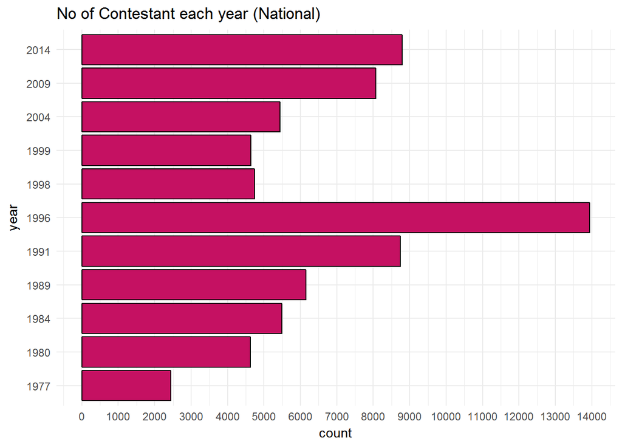

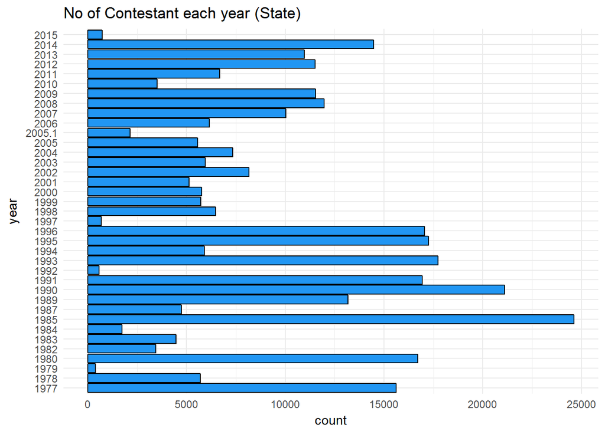

Here we can see that in the first graph(National), there is a consistent increase in number of contestant participating in the elction and goes up to 14000 in 1996.But after that it comes to less than 5000 in 1998 and it decreased even further in 1999.

The increase in 1996 could be because so many independent cadidate contested as it was the first election after india became an open economy which give indian citzen too many opportunities and contesting election was one of that.

In the second graph(State), there is not much we can say as each year few particular states went to polls. Though we can say that 1985 is the year when almost 25000(highest) contested in the elction.

## 2.Number of contestant based on gender.

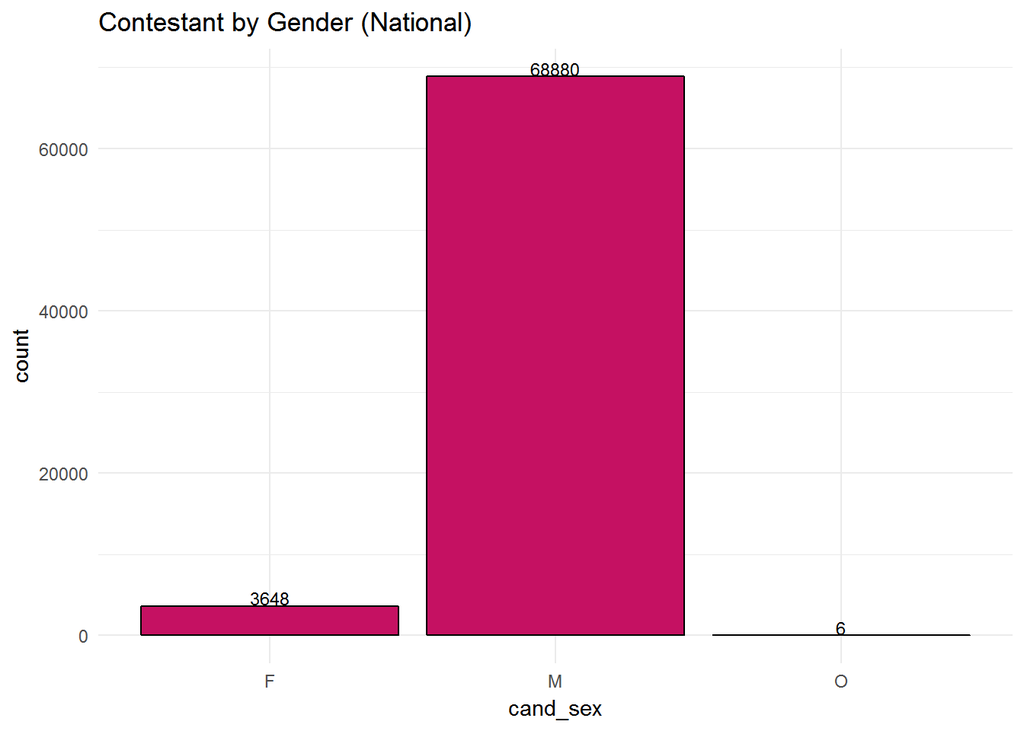

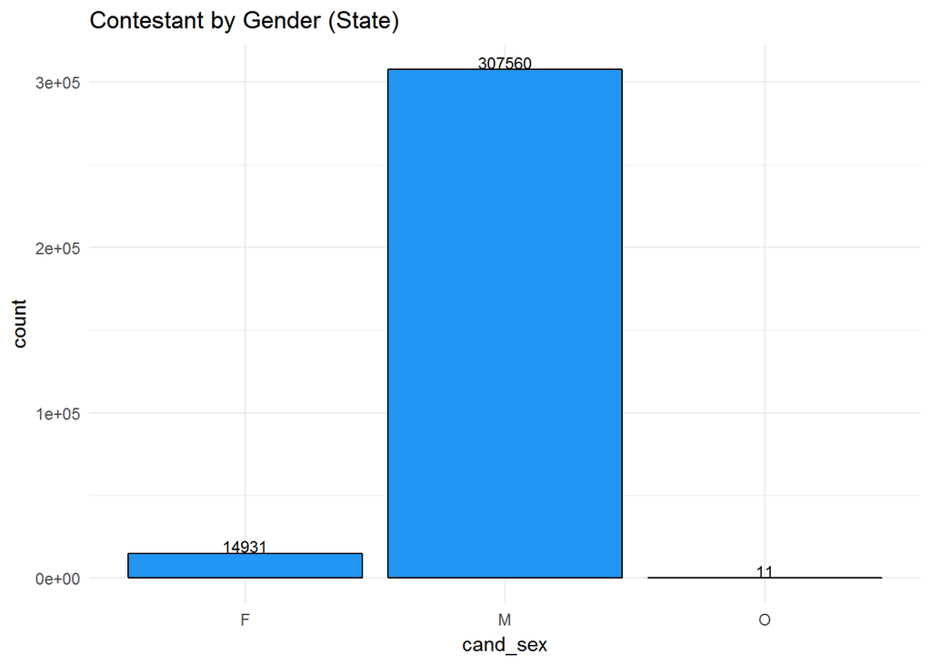

In both the graphs we can see how Men can easily out numbered the womens in politics.womens had contested almost less than 5 percent as compared to mens. The other sex(or LGBT) has a long way to go in the indian politics as far as the numbers are concern. It will be more intrsting to investigate how many women out of the few who contested did well in the elections.

## 3.Number of contestant based on State.

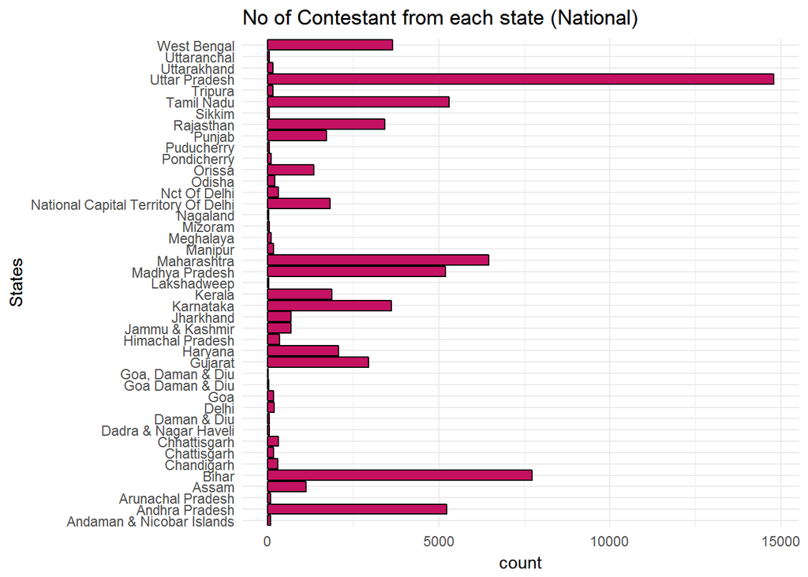

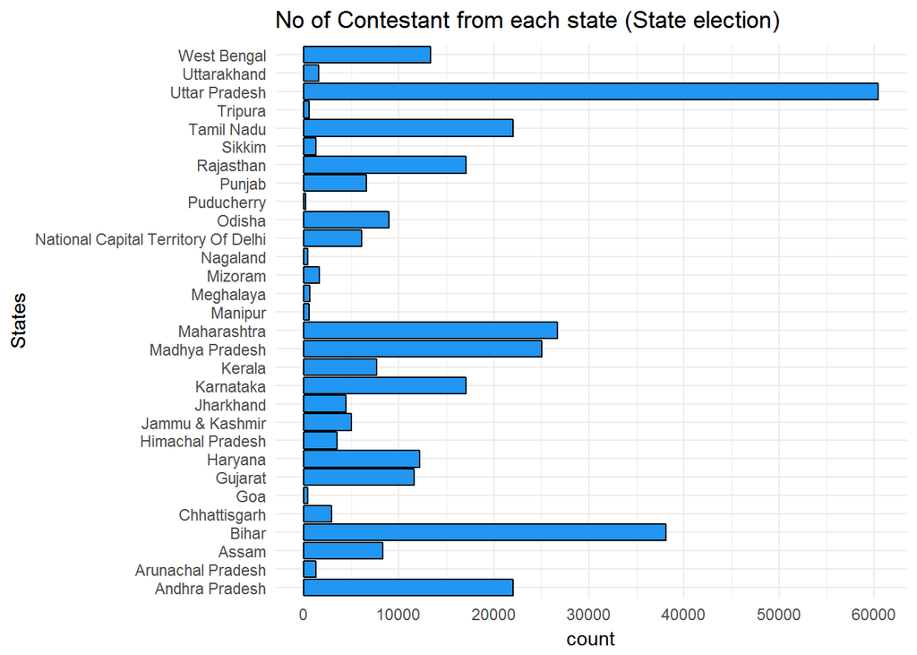

The data may look surprising but not too much for an Indian who is aware of political system of the conuntry.

**Bihar** and **Uttar pradesh** have been for a long time a hub for political revolution. which gives a mojority of polititians to the country.

**West Bengal** had been in a communist based government for almost 40 years out of 70 years of india’s history which always believed to have a not so loving attitude toward democracy. this could explain how **West Bengal** ended up having less candidate despite have large population.

## 4.Distribution of Proportion get by candidates

First lets see the summary of total vote polled.

#### National Election

```
##    Min. 1st Qu.  Median    Mean 3rd Qu.    Max.
##      11     872    2744   49838   19193  863358
```

[output not shown]

#### State Election

```
##    Min. 1st Qu.  Median    Mean 3rd Qu.    Max.
##       0     290    1023    9304    9183  584098
```

Now lets see the summary of vote proportion.

#### National Election

```
##      Min.   1st Qu.    Median      Mean   3rd Qu.      Max.
## 0.0000103 0.0007910 0.0025294 0.0483641 0.0186860 0.6827193
```

#### State Election

```
##     Min.  1st Qu.   Median     Mean  3rd Qu.     Max.
## 0.000000 0.001810 0.006628 0.064649 0.076504 0.898501
```

**Now lets plot this**

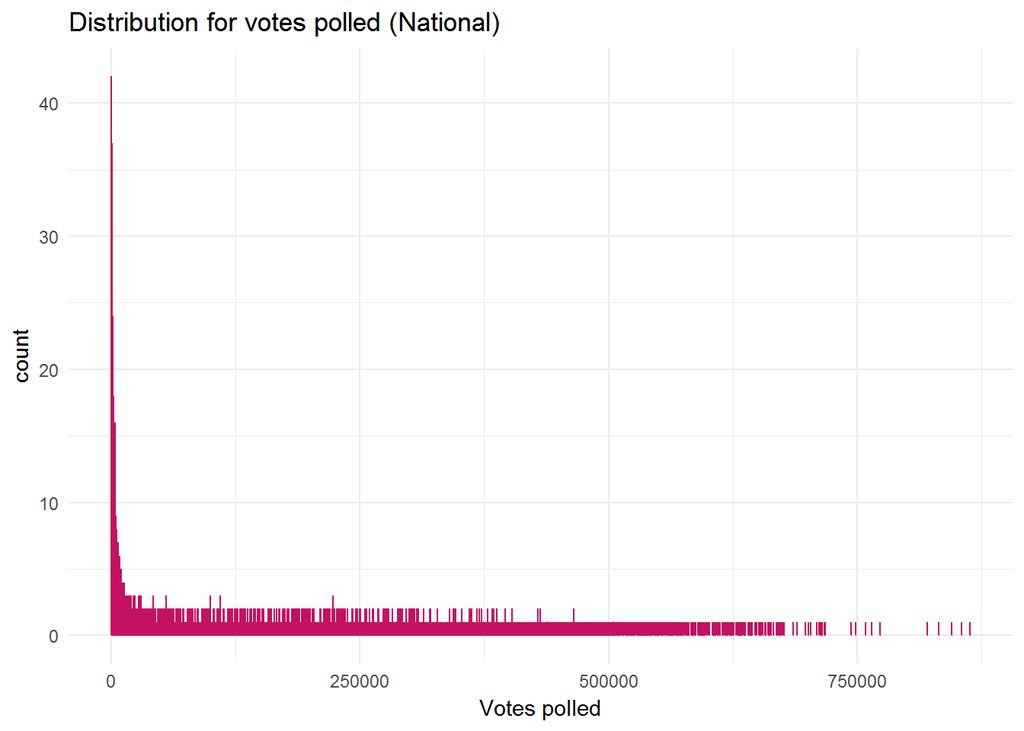

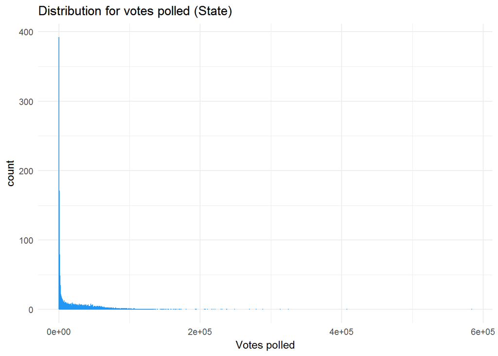

The data is highly skewed as most of the candidates lost due to few no of votes. It will be good to see the data in log10 transformation.

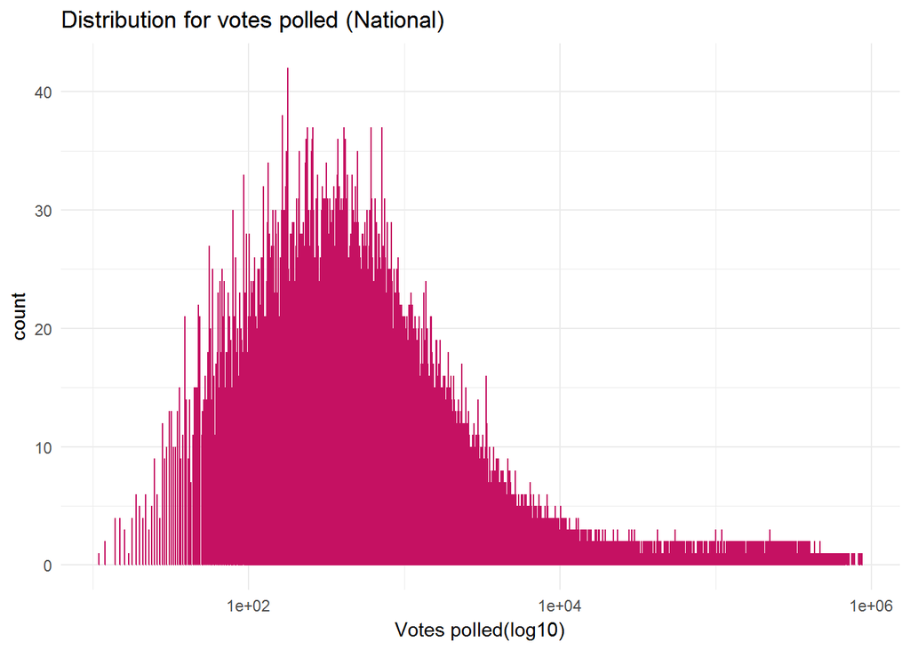

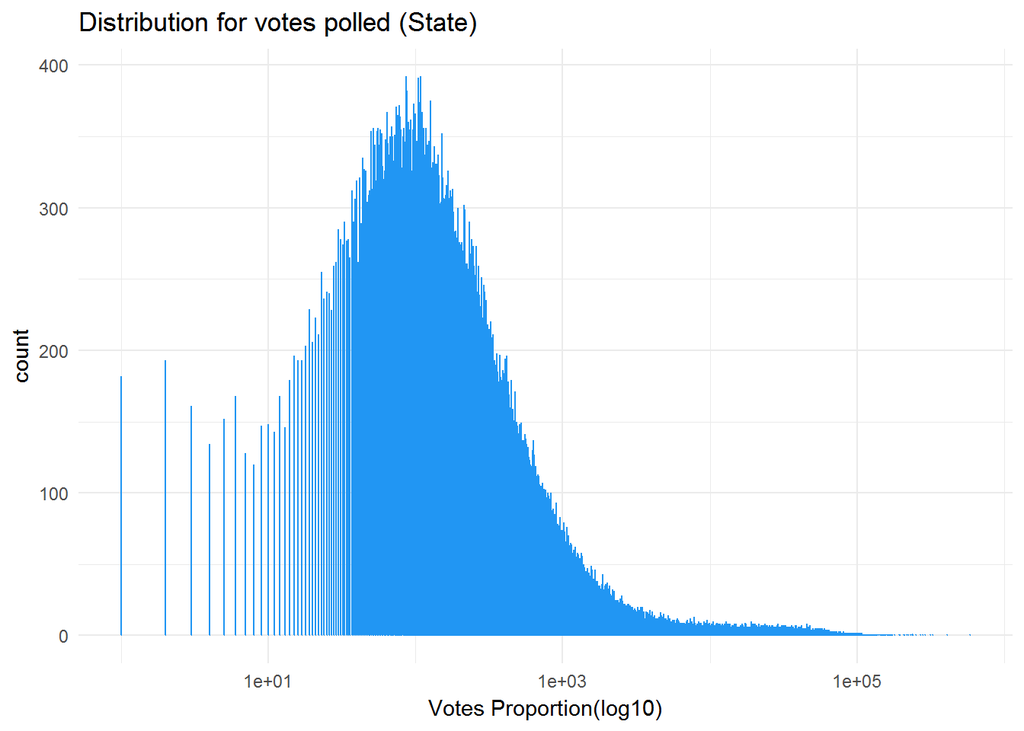

log10 transformation gives a better picture of data. We almost got a normal distribution.

## 5. Which state loves women more

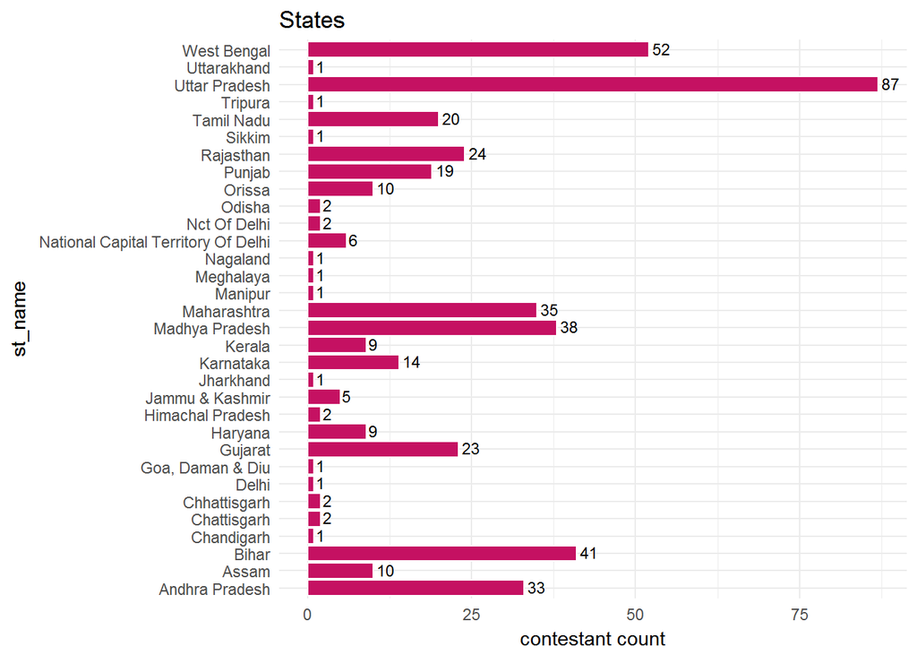

**Uttar pradesh** is at the top where maximum womens have won in the election, followed by **westbengal** and **Bihar**. There are Many states in which women politicians rarely won like **tripur**, **sikkim**, **jharkhand** etc.

## 6. Cast Divison In Parliament

India is a cast Based society, It thousands of casts which play an important role in election, there are some reserved seats in the parliament on which candidates from a particular cast can contest. Lets see how many cast reserve seats have been in the parliament through out the years of election.

There are two main cast who has reservation

**1)** Schedule cast(SC) **2)** Schedule cast(ST)

Every body else contest in **genral** category.

```
##       GEN   SC  SC    ST
##    0 4185  793    0  408
```

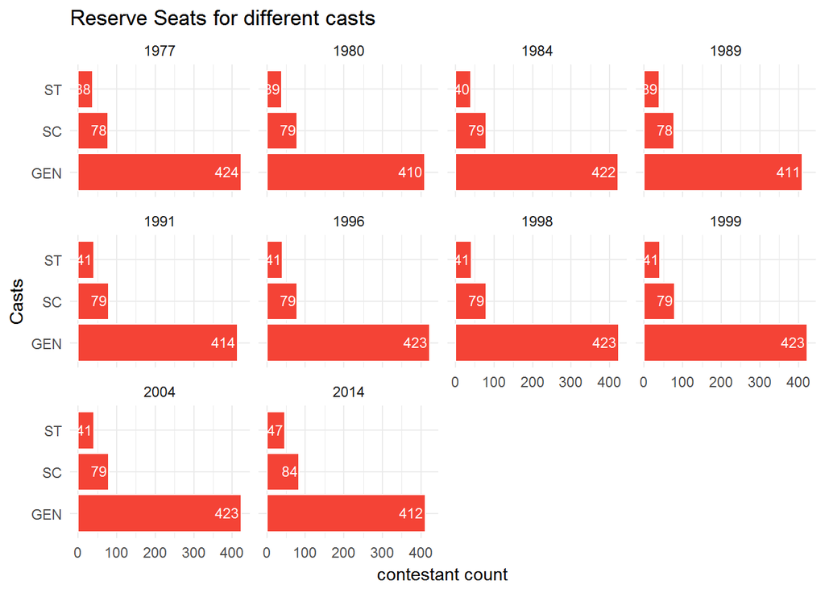

We can see from above that the seats reserves for candidates from particular cast are barely increased. for **SC** it is from **78** in **1977** to **84** in **2014** and for **ST** it went from **38** in **1977** to **47** in **2014**.

This may reflect that cast dominance is incresed in India through out these years.

# Univariate Analysis

### Structure

The structure of National election data is simple. As seen at the start of the analysis. each row represents a candidate contested for a particular year. we have **11** columns:

- st_name (Name of state)
- year (year of election)
- pc_no (parliamentry constituency no)
- pc_name (parliamentry constituency name)
- pc_type (parliamentry constituency type)
- cand_name (candidate name)
- cand_sex (candidate sex)
- partyname (political party name)
- partyabbre (party’s short form)
- totvotpoll (total votes candidate get)
- electors (total electors present in the constituency)

st_name, pc_name, pc_type, cand_name, cand_sex, partyname and partyabbre are of type **factor** and year, pc_no, totvotpoll and electors are of type **integer**.

### Main feature(s) of interest

party_name, st_name, year, cand_sex are essential feature of intrest which allowed me to answes much fundamental questions like-

- Which state has most electors?
- Does women in India has the capacity to run for election?
- Which year we see the most candidate run for election?

and many more question.

### Other features which will help support my investigation into my feature(s) of interest?

totvotpoll, electors are the other two main feature which will help me explore few more relation ship like-

- How vote share differs among gender?
- How vote share differ based on electors?
- Are independent candidates able to attract votes through out the years?
- How states differ in vote shares?

### Did you create any new variables from existing variables in the dataset?

I made three new variable -

- **proportion** - how much portion of the total electors a candidate get.
- **win_vote** - The vote share of the winning cadidate for that constituency in that year.
- **won** - represents a particular candidate won the election or not.

### Unusual distributions and its remedy

There are constituencies whose win_vote is 0. which cannot be true. The reason might be that election could be halted for that constituency by the court or election comminsion, which happened manier times in india. So I removed those entries as a outliar.

### Observations

- Among all the election 1996 is the year where maximum candidates contested the election.
- Other gender and female candidates are way fewer than the male candidates.
- Most of the candidates are from **Uttar Pradesh**(most populated state). But **west Bengal**(4th populated state) after having a huge population stands 7th in the no of candidate contested.
- Most of Winning women candidate are from **Uttar Pradesh** followed by **west Bengal**.
- Seats reserved for SC and ST has increased through out the years.

# Bivariate Plots and analysis

Now we are going to dig a little deeper in our analysis by adding one more dimension based on what we saw intresting in above plots.

## 1. Proportion based on gender

```
## Nat_election_gender$cand_sex: F
##      Min.   1st Qu.    Median      Mean   3rd Qu.      Max.
## 0.0000214 0.0010392 0.0040463 0.0704614 0.1110793 0.5154583
## --------------------------------------------------------
## Nat_election_gender$cand_sex: M
##      Min.   1st Qu.    Median      Mean   3rd Qu.      Max.
## 0.0000103 0.0007745 0.0024392 0.0475199 0.0175360 0.6827193
## --------------------------------------------------------
## Nat_election_gender$cand_sex: NULL
## NULL
## --------------------------------------------------------
## Nat_election_gender$cand_sex: O
##      Min.   1st Qu.    Median      Mean   3rd Qu.      Max.
## 0.0007498 0.0009032 0.0013373 0.0014541 0.0020291 0.0022823
```

```
## St_election_gender$cand_sex:
## NULL
## --------------------------------------------------------
## St_election_gender$cand_sex: F
##     Min.  1st Qu.   Median     Mean  3rd Qu.     Max.
## 0.000000 0.002022 0.007667 0.075489 0.123274 0.775195
## --------------------------------------------------------
## St_election_gender$cand_sex: M
##     Min.  1st Qu.   Median     Mean  3rd Qu.     Max.
## 0.000000 0.001768 0.006574 0.064778 0.077032 0.898501
## --------------------------------------------------------
## St_election_gender$cand_sex: O
##      Min.   1st Qu.    Median      Mean   3rd Qu.      Max.
## 0.0003962 0.0008385 0.0018221 0.0083610 0.0045006 0.0695342
```

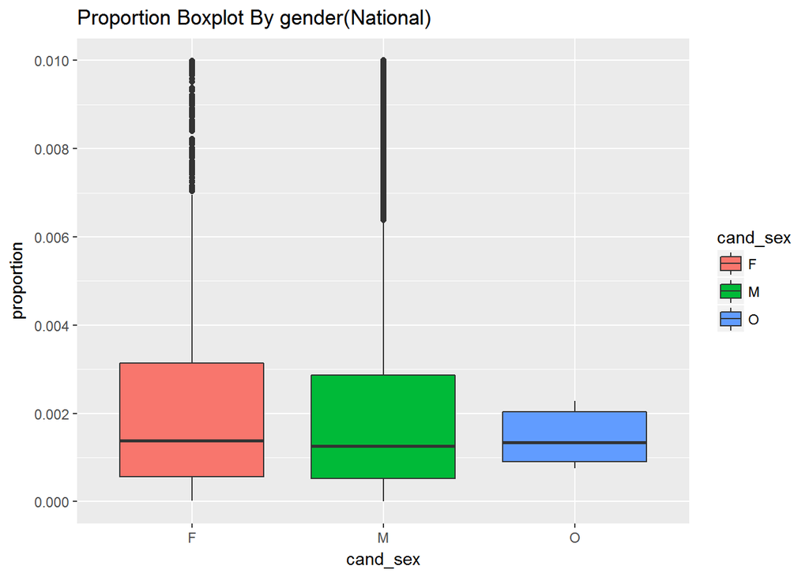

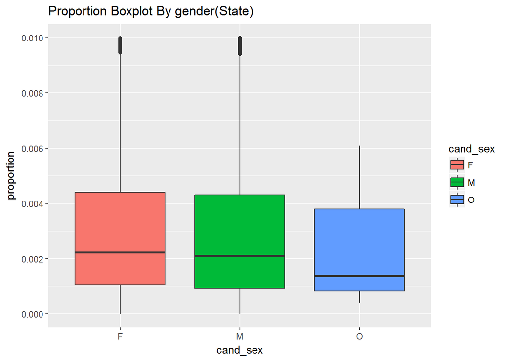

From the above Boxplot and summary we can say that most women in percentage has little bit better proportion of votes than men. Though women candidates are few, We have to see the female contribution as compared to men a little bit closer.

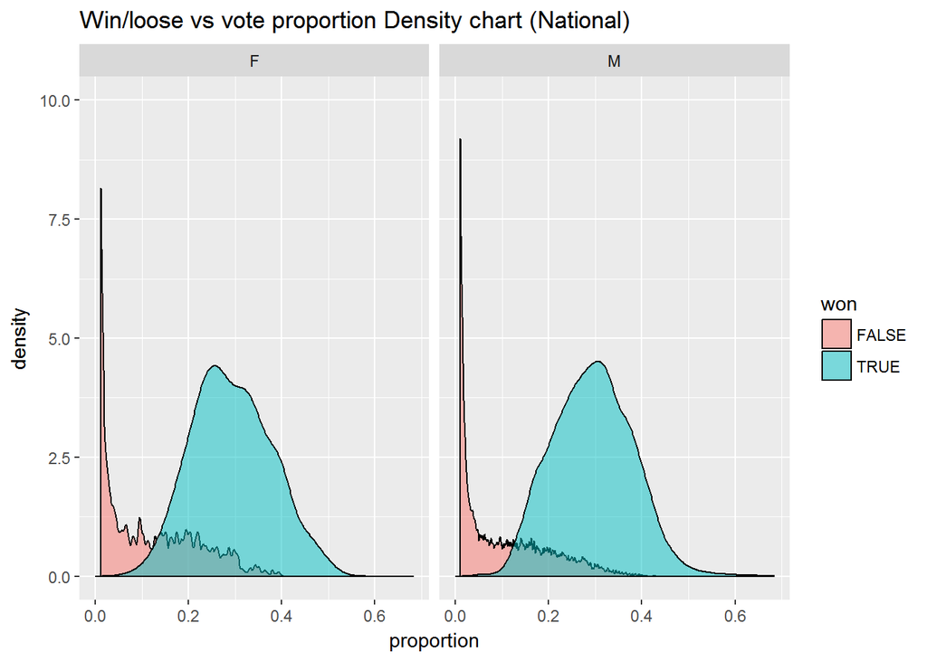

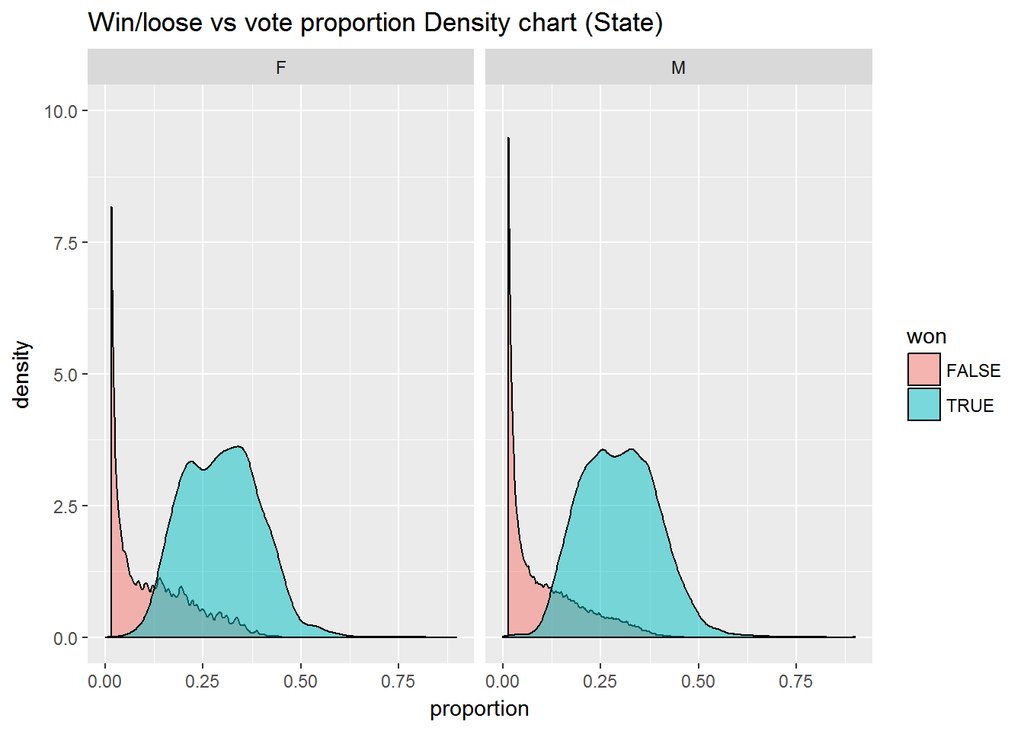

We can see that both men and women who won the election share same distribution of proportion.

## 3. Women candidate By party

Lets see which party fielded more women candidate through out the years and how being in a party effect the winning of a women candidate.

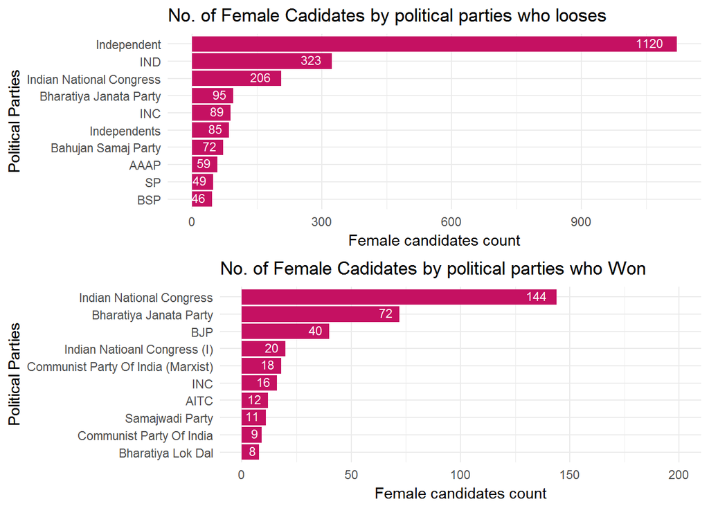

Here we can see that among top 10, the most of the womens contested as **Independent** and lost, It is very Hard for a women to contest and win an election as independent. But on the other hand if contesting women is in a political party, her chances to win is better.

**Indian National Congress** is at the top most political party whoose winning women candiate is higher than any other party followed by **Bhartiya Janta Party**.

## 3. Male candidate By party

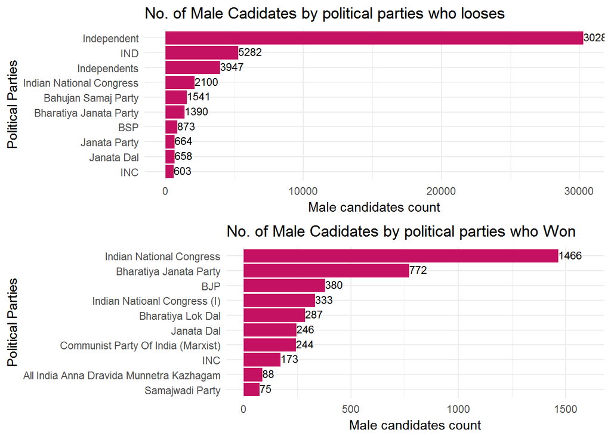

From the above data we can say that not just female, Infact male candidates are also vulnerable to faliure if they contested election as Independent. And the cances of winning is more if candiates belongs to a palititcal party.

## 4. Votes polled By state

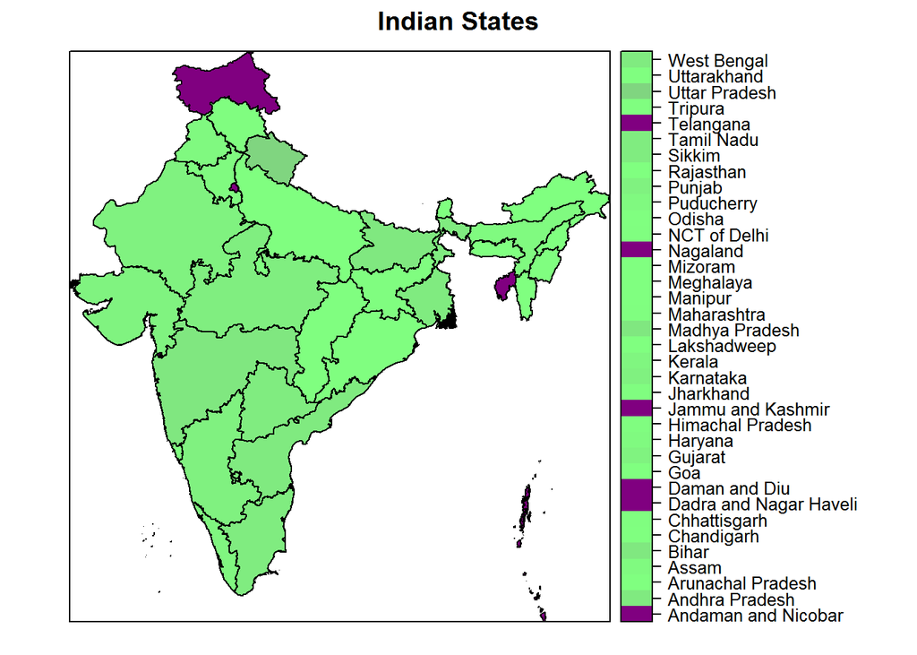

## 4.Rise And Fall Of Women.

Here we are going to see how many female cadidate make it to the parliament in the election.

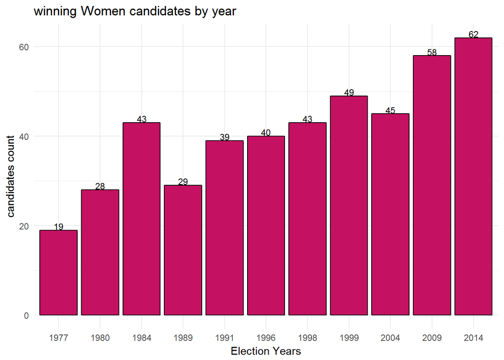

As happy to see a slow but yet progressive trend for women taking more seats in parliament through out the years.

## 5.Rise and fall of women’s charisma

Here we are going to see how women candiate’s vote proportion varies through out the years.

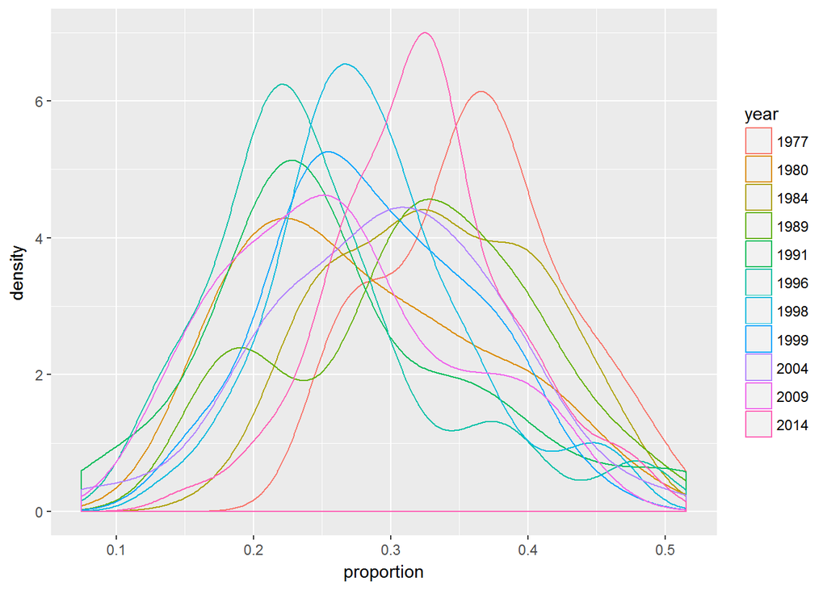

## 6. Respond to Independent’s Call

Here we see the the performance of independent candidate through out years.

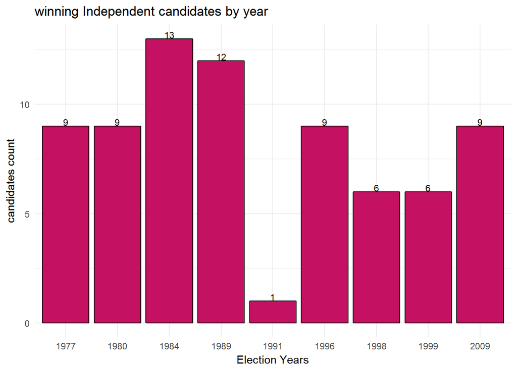

According to the above graph 2014 is the worst year for independent candidates where not single won the election. It is followed by the 1991 election where only 1 candidate won.

To conclude this we can say that Elections in india is a tough job for an Independent candidate rather than a candidate with a political party in his/her back.

## 7. States concious of democracy

Here we see the votepolled out of total electorats in each state.

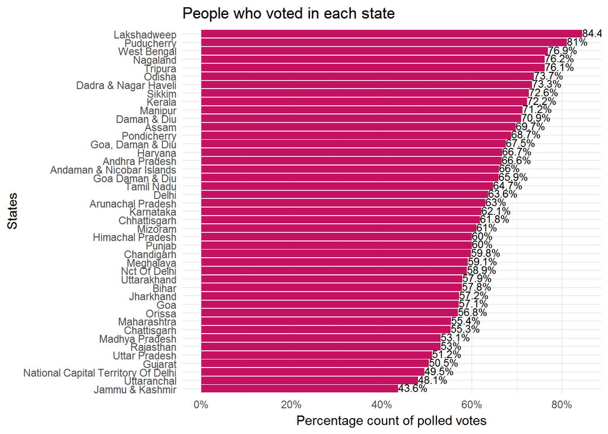

Above Bar Graph shows that Lakshdweep an island which is not a state but a union territory has the people which are more concious about election than any other state.

One intresting things in the above chart is that states like **West bengal**, **Nagaland**, **Tripura** which are suffering from gross insurgent military groups in their region has the high vote percentage than other states.

**Kerela** which is the most literate state in the country is also in the top 10.

## 8. Proportion vs Electors

we are going how much a candidate gathere vote based on the electors size in his constiuency.

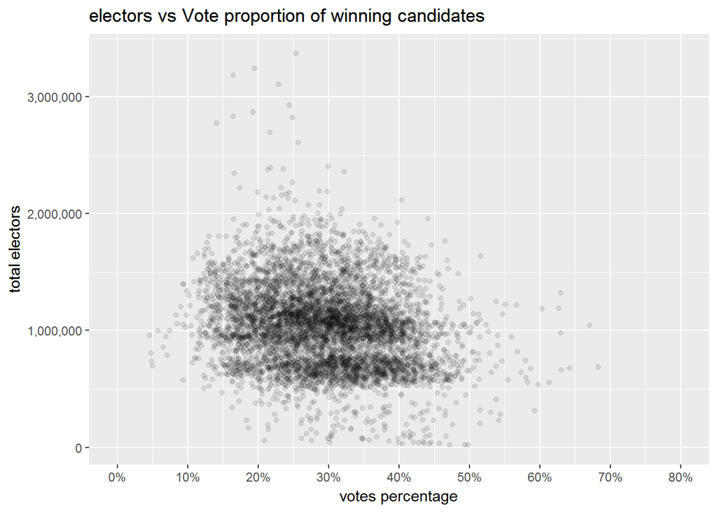

In above scatter plot we can see that most of the candidates won at a prcentage range of 15 to 45 there are very few winning candidate with less than 10% of vote share, also there are very few candidates with vote share grater than 50%.

Lets look it in different years.

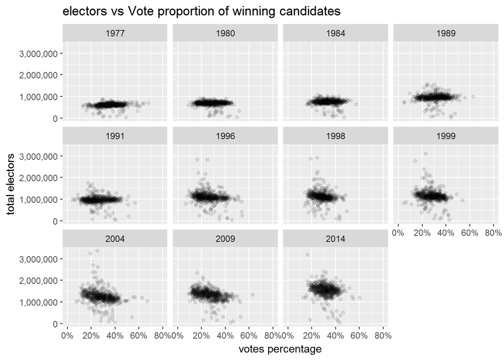

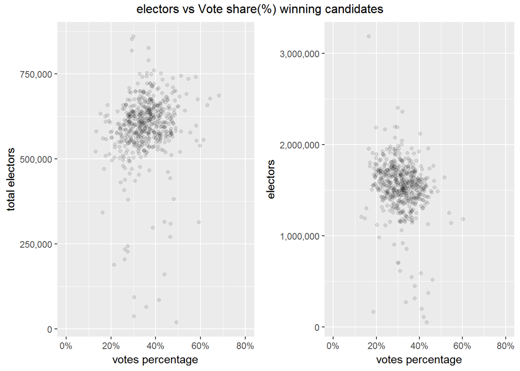

In the First scatterplot(facet by years) we can see a pattern, more are more candidates in every metioned year got a similar vote share but at a much higher total electors.

The very shift in the total electors we can see in the second graph which is of the first election(1977) and the last(2014). Also the variance in 1977 election is greater than in 2014.

There could be two reasons for this:

**1.** Due to population growth.

**2.** Due to a consistent use of politics of populism.

We will investigate furthur on our second point.

# Bivariant Analysis

### Strongest Relationship

The most strongest relation is between the electors and the vote percentage. Most of the winning candidate have the vote share between 20% to 40% but it is less likely to have a higher vote share when total electors are very high.

Also it is very less likely to have a vote share of more than 50% even for a small value of total electors.

Another intresting point in the above relation is that as every next election the electors increses but the variance in the proportion gets slightly decreased.

# Multivariate Plots Section

## 1. Electors vs proportion by year

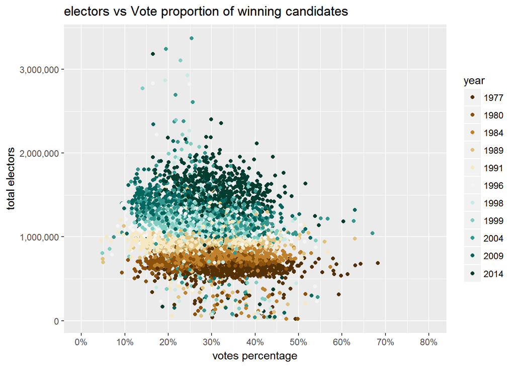

Here the cange is color as we go down to up in total electors represents the population growth through out the years, but also we are looking at a decrease in variance as we grow in poulation.

## 2.Electors vs Vote share By Gender

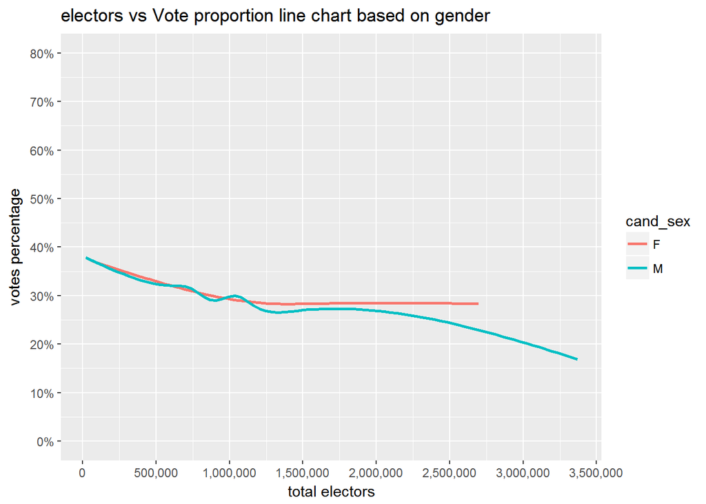

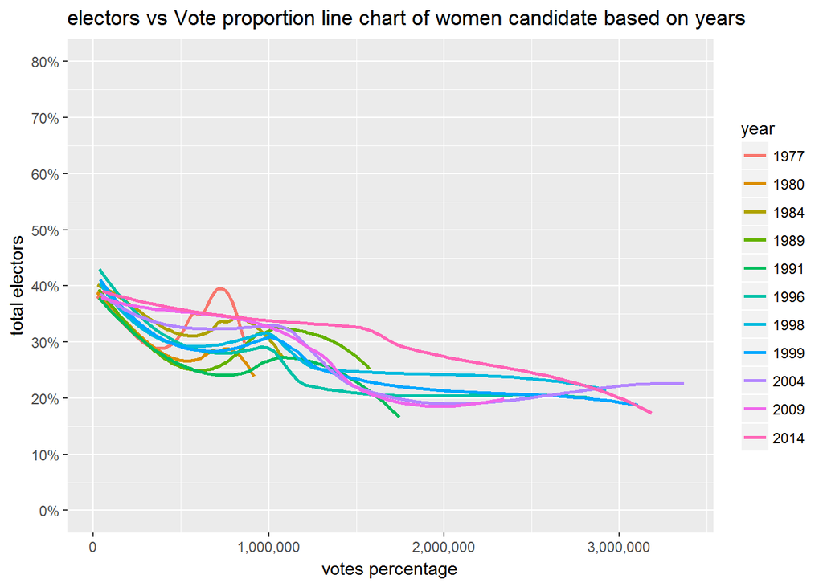

In the first chart we can see that women did better in getting higher votes in constituencies with large electors then men.

In the seconds graph we can see that 2014 has been one of the most successfull year for women candidates for larger constituencues in getting higher vote share.

## 3.Top Political Parties

Now we are going to see how the vote share varies in top political parties through out the year.

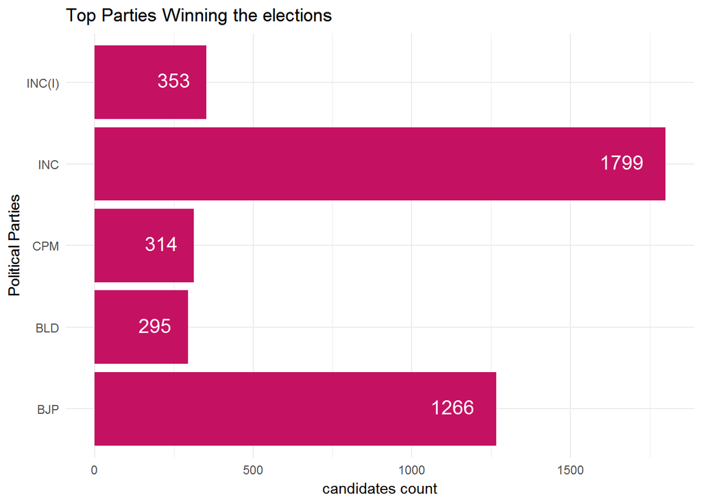

We can see that out of top five parties two parties have the largest share which are the **BJP** and **INC**.

```
## top_parties$year: 1977
##    BJP    BLD    CPM    INC INC(I)
##      0    295     22    152      0
## --------------------------------------------------------
## top_parties$year: 1980
##    BJP    BLD    CPM    INC INC(I)
##      0      0     37      0    353
## --------------------------------------------------------
## top_parties$year: 1984
##    BJP    BLD    CPM    INC INC(I)
##      2      0     22    414      0
## --------------------------------------------------------
## top_parties$year: 1989
##    BJP    BLD    CPM    INC INC(I)
##     85      0     33    197      0
## --------------------------------------------------------
## top_parties$year: 1991
##    BJP    BLD    CPM    INC INC(I)
##    120      0     35    244      0
## --------------------------------------------------------
## top_parties$year: 1996
##    BJP    BLD    CPM    INC INC(I)
##    160      0     32    141      0
## --------------------------------------------------------
## top_parties$year: 1998
##    BJP    BLD    CPM    INC INC(I)
##    182      0     32    141      0
## --------------------------------------------------------
## top_parties$year: 1999
##    BJP    BLD    CPM    INC INC(I)
##    181      0     33    115      0
## --------------------------------------------------------
## top_parties$year: 2004
##    BJP    BLD    CPM    INC INC(I)
##    138      0     43    145      0
## --------------------------------------------------------
## top_parties$year: 2009
##    BJP    BLD    CPM    INC INC(I)
##    116      0     16    206      0
## --------------------------------------------------------
## top_parties$year: 2014
##    BJP    BLD    CPM    INC INC(I)
##    282      0      9     44      0
```

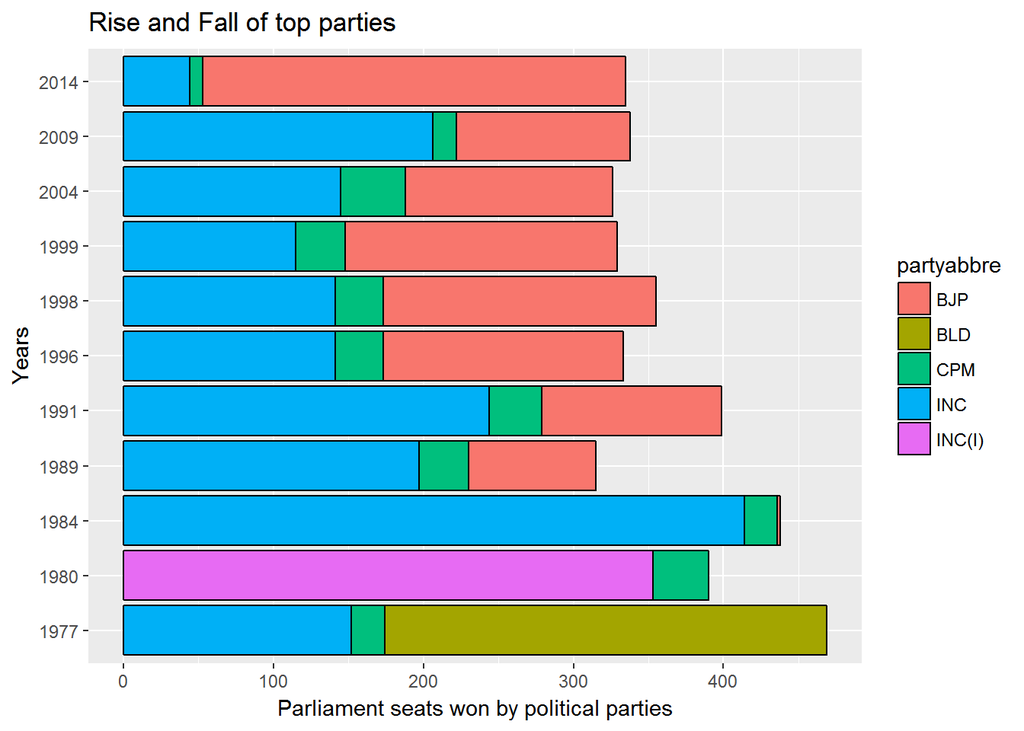

From the above summary we can say that INC(Indian National congress) has been the most dominating party through out the years, But we see a fascinating shift in 2014 where INC went down to 44 seats from 206 seats in 2009. And BJP which starts from 2 seats in 1984 went up to 282 seats in 2014.

Note:

- **BLD** is an outcome of a grand allaince(merger of many parties) to defeat **INC**. They won the election but the party as well their government didn’t last.
- **INC(I)** was a new party but with the old politicians of **INC**. because the court banned **INC** to contest election, so they made a new party to contest the election.

# Multivariate Analysis

# Final Plots and Summary

# Reflection